Vamsi Gudipati

Portfolio · Wall sensing · October 2026

# Reading the flow off the wall: near-wall velocity from wall shear stress, and how far up it works

**Vamsi Gudipati** 1-D U-Net · Wall modelling · Baselines · Generalisation splits [Repository](https://github.com/vamsigudipati/wall-shear-to-near-wall-velocity)

0.19 / 0.39

U-Net error over the target's spread at y+ = 5 and 10, later snapshots held out

2–3×, not 1,000×

the margin over the wall law, once the law is written correctly

y+ ≈ 30

where the wall stops informing the flow: nothing beats the mean beyond it

10–17 %

how much a random split over neighbouring planes flatters the learned models

300 epochs: no gain

twice the training budget: same error at y+ = 5 and 10, worse at 15 and 30

## Objective

The wall is the one place in a turbulent flow where a sensor is easy to put and a simulation is hardest to resolve. If the velocity a few wall units above the surface could be read off the wall shear stress, a wall model or a sensor array could stand in for the finest part of the grid. This project asks how far up that works, with one network and the references that a careful engineer would try first. The work is three stages, each a notebook:

1. **Stage 1 — A 1-D U-Net from the wall shear stress to the velocity at y+ = 5 and 10.** From 5,777 planes of a turbulent channel simulation, 11,554 lines of the wall gradient du/dy along x (two walls per plane) are mapped by a 1-D U-Net to the streamwise velocity at y+ ≈ 5 and 10 along the same line.
2. **Stage 2 — Height and generalisation: ridge, the wall law and three splits.** The same question at five heights up to the channel centre, against ridge regression on the same input and the correct first-order wall law, and on three splits: the random one, later snapshots held out, and whole spanwise planes held out.
3. **Stage 3 — The height experiment with twice the training budget.** Stage 2's U-Nets all stopped at a 150-epoch cap; this stage trains the five-height U-Net to 300 epochs on the two honest splits to settle whether the cap was hiding a better network.

Every training is repeated with seeds 0, 1 and 2, seed 0 being the base run. The data are the same channel-flow planes as my U-Net project, so this repository points at that release rather than uploading them again.

## Problem statement

Given τ_w(x), the wall-normal gradient of u at the wall along a line of 384 points, predict u(x) at a height y+ above that wall. Near the wall the answer is almost given away: in the viscous sublayer u grows linearly with the distance, so u ≈ (du/dy) · y is a reference that costs nothing. The question is what a network adds to that law, at what height the wall stops informing the flow, and whether the number depends on how the data are split.

[figure not shown]

**The path.** Planes of u become wall-gradient lines and target lines; a 1-D U-Net maps one to the other; the wall law, the training mean and small networks are the references; the error is measured per height on held-out lines, with seeds and three splits.

[figure not shown]

**The data and the split.** 107 snapshots with 50 to 60 spanwise planes each; both walls of every plane give a line, with the sign of the gradient telling which wall. The random split sends 95 % of the validation lines next to a training neighbour one plane away, and the normalisation uses all lines, validation included.

## Method

### Wall units and the first-order law

The friction velocity u_τ = √(ν |du/dy|) sets the wall unit; y+ = y u_τ / ν, and Re_τ ≈ 125 for these planes. In the viscous sublayer (y+ below about 5) the velocity is linear in the distance, u+ = y+, which in the stored units reads u ≈ (du/dy) · (y − y_wall). The original notebook's baseline writes it as u = u_τ · y+ with u_τ = √|τ_w| and keeps the sign of the top wall's gradient, which leaves out the viscosity and flips the sign at one wall: that baseline is 13.6 and 27.2 in error at the two heights, about a thousand times the network's, and the comparison in the notebook rests on it. Stage 2 restores the law.

### The network

[figure not shown]

**The 1-D U-Net.** Four levels of paired convolutions with 16 to 128 filters, a 256-filter bottleneck, max-pooling down and transposed convolutions up with skip connections, and a 1 × 1 convolution to two outputs: u at y+ 5 and 10. 677,122 weights.

[figure not shown]

**One training step.** Mean squared error on the normalised targets, Adam at 1e-4 with gradient clipping, batch 32; the learning rate halves after 6 flat epochs and training stops after 15, restoring the best weights.

The network sees a whole line at once. Its receptive field, measured by the gradient of one output point with respect to the input, spans 188 points, 94 on each side: half the line. The periodic direction x is zero-padded at the ends, so the error is largest at x = 0.

### References, and three ways to hold data out

Stage 2 scores every model as the root-mean-square error divided by the target's own spread, so that 1 is the error of predicting the training mean and the heights can be compared. Ridge regression maps the 384 wall values to the 384 target values linearly; it needs the gradient taken into the fluid at both walls (the top wall multiplied by −1), because on the raw signed input it is no better than the mean. The first-order law and the training mean are the other references. The three splits are the random one of Stage 1, the last 20 % of snapshots held out whole, and the spanwise planes labelled 48, 49 and 80 to 89 held out, so that only one test plane has a training neighbour.

### Which device

One training step of the U-Net inside `model.fit` takes 15.6 ms on the CPU and 81 ms on the Apple GPU (batch 32, median of 30 steps after 10 warm-up steps); the small reference networks are 5 to 6 times faster on the CPU too. Everything runs on the CPU, which the original notebook already assumed.

## Implementation

What was run, and with what.

| Item | Choice |
| --- | --- |
| Environment | Python 3.12, TensorFlow 2.18.1, Keras 3.6; Apple M3 Max, CPU |
| Data | 5,777 HDF5 planes of u on a (y, x) grid of 201 × 384 from the channel-flow simulation at Re_τ ≈ 125; wall gradient at both walls, u at the grid rows nearest y+ = 5 and 10 |
| Lines | 11,554 (two walls per plane), 384 points each; normalised by the mean and standard deviation of all lines |
| Stage 1 | 1-D U-Net, 16 base filters, 4 levels, kernel 3, no dropout; Adam 1e-4, clipnorm 1, MSE, batch 32, up to 300 epochs, patience 15 / 6; random split 9,243 / 2,311 (seed 24). Extensions: five heights at o… |
| Stage 2 | Heights y+ = 5, 10, 15, 30 and the centre; U-Net capped at 150 epochs; ridge on the sign-corrected gradient; the first-order law; the training mean; splits random, later snapshots, spanwise planes; er… |
| Stage 3 | The five-output U-Net (677,173 weights) on the later-snapshots and spanwise-plane splits, up to 300 epochs with the same early stopping, 45-minute cap; ridge, the law and the mean recomputed; single r… |
| Seeds | 0, 1, 2 for every training (the base U-Net trains in 11.5 minutes); seed 0 is the base run |
| Run time | Stage 1 81 min, Stage 2 97 min, Stage 3 44 min, one at a time |

## Results 1 — The U-Net, and the baseline it was measured against (Stage 1)

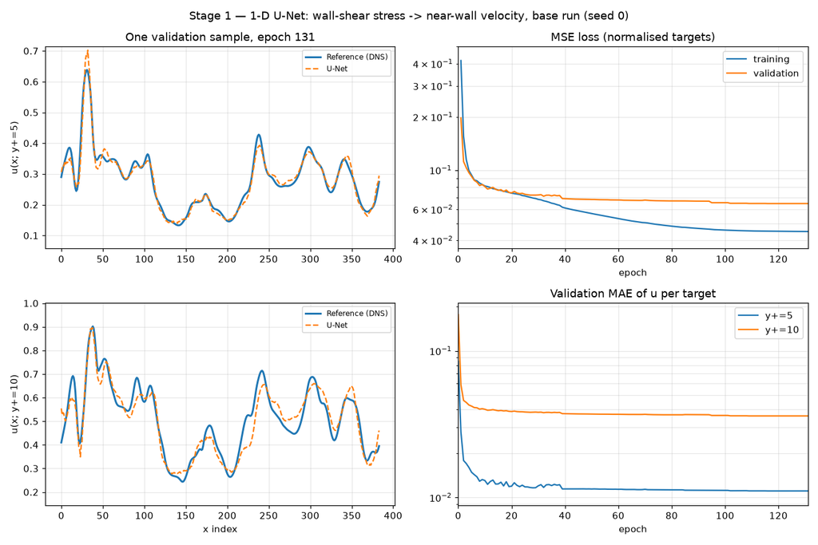

**The base run after 131 epochs.** At y+ = 5 the prediction follows the simulation almost point for point; at y+ = 10 it keeps the peaks and troughs and loses some amplitude. The validation loss stops improving after about 40 epochs while the training loss keeps falling.

[figure not shown]

**Against the references, on a log scale.** The notebook's law is three orders of magnitude off; with the viscosity restored it is 4 and 2.7 times the U-Net's error; the correct first-order law 2.2 and 3.3 times; a single convolution block of 882 weights 1.3 and 1.6 times.

Mean absolute error of u in the stored units, validation lines of the random split; the networks are the mean of three seeds.

| Model | MAE at y+ = 5 | MAE at y+ = 10 |
| --- | --- | --- |
| Law as written in the notebook | 13.6 | 27.2 |
| Law with the viscosity restored | 0.0429 | 0.0985 |
| First-order wall law, correct sign | 0.0249 | 0.121 |
| Training mean | 0.079 | 0.126 |
| One convolution block, 882 weights | 0.0147 | 0.0567 |
| 1-D U-Net, 677,122 weights | 0.0111 ± 0.00004 | 0.0362 ± 0.0002 |

The U-Net is the best model at both heights, and its seed spread is tiny. But the margin is 2 to 3 times over the correct law, not a thousand, and a convolution block with 770 times fewer weights gets within 30 to 60 % of it. At y+ = 5 the law alone already beats the training mean by three times; at y+ = 10 it does not.

[figure not shown]

**The U-Net's variants and the small references.** Five heights at once costs little (0.0126 and 0.0391); a dense network is far worse than a single convolution block; trained on all planes and scored on held-out snapshots the U-Net keeps its error (0.0123, 0.0401), but trained on one plane with 32 filters it does not (0.0333, 0.0643).

[figure not shown]

**Five heights at once.** The error grows from 0.013 at y+ = 5 to 0.08 at y+ = 20 and 30, then falls at 50 because the velocity itself varies less there; measured against 10 % of the mean velocity at each height, the error is below that mark up to y+ = 15 and level with it at 20.

[figure not shown]

**What one output point looks at.** The gradient of the prediction at x_i with respect to the input is non-zero from 94 points upstream to 93 downstream, with the largest weights within a few points of x_i.

## Results 2 — How far up the wall informs the flow (Stage 2)

[figure not shown]

**Error over the target's spread against height, on later snapshots held out** (both axes logarithmic). The U-Net is below ridge at y+ = 5, 10 and 15 by more than its seed range; at 30 the two overlap near 0.95; at the centre neither beats the mean. The first-order law passes 1 before y+ = 10 and is off the chart above 15.

RMSE divided by the target's standard deviation; 1 is the error of predicting the training mean. Fitted on the first 80 % of snapshots, scored on the last 20 %.

| y+ | Target spread | U-Net (3 seeds) | Ridge | First-order law | Training mean |
| --- | --- | --- | --- | --- | --- |
| 5 | 0.0955 | 0.191 [0.188, 0.195] | 0.217 | 0.358 | 1.001 |
| 10 | 0.1468 | 0.392 [0.374, 0.405] | 0.481 | 1.111 | 1.001 |
| 15 | 0.1557 | 0.611 [0.576, 0.633] | 0.710 | 2.398 | 1.001 |
| 30 | 0.1295 | 0.946 [0.878, 0.989] | 0.981 | 8.477 | 1.001 |
| Centre (125) | 0.0500 | 1.040 [1.001, 1.098] | 1.113 | 139 | 1.025 |

The wall gradient informs the viscous sublayer and the lower buffer layer and little beyond. At y+ = 5 the U-Net removes 81 % of the target's spread and ridge 78 %; at 10 they remove 61 % and 52 %; at 15, 39 % and 29 %; at 30 the U-Net is within a few per cent of the mean predictor and ridge is at it; at the centre every model is worse than the mean. The network's advantage over a linear map is real but modest, about 0.03 to 0.1 of the spread, and it closes as the height grows.

### The split changes the number

[figure not shown]

**The same models on three splits at y+ = 5 and 10.** The random split of Stage 1 gives both learned models their lowest error; holding out later snapshots or whole spanwise planes gives the same, higher number, 0.39 for the U-Net at y+ = 10 against 0.34.

RMSE over the target's spread; the U-Net is the mean of three seeds. The plane split holds out the planes labelled 48, 49 and 80 to 89.

| Model | Random (Stage 1) | Later snapshots | Spanwise planes |
| --- | --- | --- | --- |
| U-Net, y+ = 5 | 0.173 | 0.191 | 0.191 |
| U-Net, y+ = 10 | 0.336 | 0.392 | 0.394 |
| Ridge, y+ = 5 | 0.181 | 0.217 | 0.206 |
| Ridge, y+ = 10 | 0.406 | 0.481 | 0.452 |
| First-order law, y+ = 5 | 0.36 | 0.36 | 0.36 |
| First-order law, y+ = 10 | 1.10 | 1.11 | 1.12 |

The random split flatters both learned models by 10 to 17 %, because 95 % of its validation lines have a training neighbour one plane away, and neighbouring planes correlate at 0.90 to 0.98. The two honest splits agree with each other, which is the number to quote. One exception runs the other way: on the plane split at y+ = 30, ridge (0.927) beats every U-Net seed.

## Results 3 — Twice the training budget does not help (Stage 3)

The open point of Stage 2 was whether its U-Nets, all stopped by the 150-epoch cap, would improve with longer training. Stage 3 trains the same five-output U-Net for up to 300 epochs on each honest split, with the same early stopping, and scores it against the same deterministic references. One training now takes 21 to 23 minutes, over my limit for seed repeats, so these are single runs, and the only claim they can support is whether the new number falls outside Stage 2's three-seed range.

[figure not shown]

**Both trainings run to the cap.** The early-stopping loss, measured on a random 15 % of the fitting lines, keeps creeping down through epoch 300, with the learning rate halved seven times on the snapshot split and three on the plane split; neither training stopped early. The training loss keeps falling faster: the gap between the two widens.

[figure not shown]

**Later snapshots held out, error against height.** The 300-epoch U-Net (dark line) against Stage 2's 150-epoch runs (the band is their three-seed range), ridge, the law and the mean. At y+ = 5 and 10 the longer run sits inside the earlier range; at 15 and 30 it sits above it.

RMSE over the target's spread, later snapshots held out; ridge, the law and the mean reproduce Stage 2 exactly.

| y+ | U-Net, 300 epochs | U-Net, 150 epochs (3 seeds) | Outside the range | Ridge |
| --- | --- | --- | --- | --- |
| 5 | 0.1914 | 0.1915 [0.1883, 0.1947] | no | 0.2173 |
| 10 | 0.4030 | 0.3922 [0.3742, 0.4047] | no | 0.4808 |
| 15 | 0.6380 | 0.6105 [0.5756, 0.6327] | yes, worse | 0.7102 |
| 30 | 1.0012 | 0.9457 [0.8784, 0.9889] | yes, worse | 0.9805 |
| Centre (125) | 1.0663 | 1.0400 [1.0009, 1.0982] | no | 1.1126 |

[figure not shown]

**Spanwise planes held out.** The same comparison on the plane split: the longer run is inside Stage 2's range only at y+ = 5 and above it everywhere else; at y+ = 30 ridge (0.927) beats the U-Net (0.968) as it already did at 150 epochs.

The answer is no. Doubling the budget leaves the error at y+ = 5 and 10 inside Stage 2's seed range and moves it outside, for the worse, at y+ = 15 and 30 on the snapshot split (0.638 against 0.611, and 1.001 against 0.946, where the network is now exactly the mean predictor and behind ridge). On the plane split the longer run is above the earlier range at every height but y+ = 5. The training curves say why: the early-stopping lines are a random 15 % of the fitting lines, neighbours in time and span of the training lines, so they keep improving while the held-out error at the greater heights rises. The U-Net still beats ridge at y+ = 5, 10 and 15 on both splits; at 30 it does not.

Two cautions on reading this. These are single runs against a three-seed range, so "worse at 15 and 30" rests on one training; and the 300-epoch cap is still a cap, reached in both runs. The trend from 150 to 300 epochs is the evidence that going further would not help, not a converged number.

## Key observations

1. **Check the baseline before the claim.** The original comparison showed the network a thousand times better than the wall law; the law had lost its viscosity and one wall's sign. Written correctly, the network is 2 to 3 times better at y+ = 5 and 10.
2. **The wall informs about ten wall units of flow.** The U-Net removes 81 % of the target's spread at y+ = 5, 61 % at 10, 39 % at 15 and almost nothing at 30; at the centre nothing beats the mean. A wall sensor is a sublayer sensor.
3. **A linear map gets most of the way.** Ridge regression on the sign-corrected gradient is within 0.03 to 0.1 of the spread of the U-Net at every height, and ahead of it once on the plane split at y+ = 30. The network's gain is real, beyond the seed range up to y+ = 15, and modest.
4. **The split is part of the number.** A random split over neighbouring planes flatters both learned models by 10 to 17 %; held-out snapshots and held-out planes agree with each other.
5. **Neither size nor training time is the lever here.** A single convolution block of 882 weights gets within 30 to 60 % of a U-Net of 677,000, the U-Net's seed spread is below 1 % of its error, and doubling its training budget leaves y+ = 5 and 10 unchanged and makes 15 and 30 worse: the problem is nearly linear and well determined, so the architecture and the epochs buy little.
6. **Small references belong in every comparison.** The notebook's own extensions, a dense network and a convolution block, place the U-Net's result on a scale that the broken law could not.

## Conclusion

A 1-D U-Net reads the velocity at y+ = 5 and 10 off the wall shear stress with errors of 0.19 and 0.39 of the target's spread on snapshots it has never seen, better than a ridge regression on the same input by more than its seed range, and 2 to 3 times better than the correct first-order wall law, not the thousand times that the original baseline suggested. The information in the wall gradient runs out between y+ = 15 and 30, for the network and the linear map alike.

Stage 3 closes the one objection the earlier stages left: the U-Nets had stopped at a 150-epoch cap. Trained for 300 epochs on the honest splits, the network is no better at y+ = 5 and 10 and worse beyond Stage 2's seed range at 15 and 30, where the early-stopping lines, drawn from the fitting period, keep improving while the held-out error rises. The information limit between y+ = 15 and 30 is a property of the wall signal, not of the training budget.

What the stages do not establish: whether two-dimensional input (the wall shear over a patch rather than a line) extends the useful height; whether an early-stopping set drawn from later snapshots would stop the trainings where the held-out error is lowest; and how the result scales with the Reynolds number, since only Re_τ ≈ 125 was available. The next steps are a 2-D wall-patch input, early stopping on a held-out block of time, and the same comparison with the spanwise velocity and pressure at the wall added to the input, which the sublayer law does not use.

## Code, data and reproducibility

The three notebooks of the repository, each also exported as HTML with all outputs.

| Notebook | Stage |
| --- | --- |
| `01_wall_to_near_wall_unet.ipynb` | Stage 1 — A 1-D U-Net from the wall shear stress to the velocity at y+ = 5 and 10 |
| `02_height_and_generalisation.ipynb` | Stage 2 — Height and generalisation: ridge, the wall law and three splits |
| `03_height_run_to_convergence.ipynb` | Stage 3 — The height experiment with twice the training budget |

| Item | Where |
| --- | --- |
| Repository | vamsigudipati/wall-shear-to-near-wall-velocity: the three executed notebooks, result tables and figures for every experiment, split and seed, the base U-Net and the two 300-epoch U-Nets with their nor… |
| Data | The 5,777 planes come with the [unet-turbulent-fields release](https://github.com/vamsigudipati/unet-turbulent-fields/releases/tag/v1.0) (`u_yx_planes_h5.tar`, 1.6 GB, SHA-256 in the README); no secon… |
| Environment | `requirements.txt` in the repository (Python 3.12, TensorFlow 2.18.1, Keras 3.6) |
| Run | About four hours on a laptop CPU, one stage at a time |